# Step 1: Imports and Initial Configuration

This cell handles the initial setup of our project.

- **Libraries:** We import all the necessary libraries for image processing (`OpenCV`, `scikit-image`), data manipulation (`pandas`, `numpy`), machine learning (`scikit-learn`, `xgboost`), and visualization (`matplotlib`, `seaborn`).
- **Global Constants:** We also define several key constants that will be used throughout the notebook. This makes the code cleaner and easier to modify.
  - `WINDOW_SIZE`: The dimension (in pixels) of the sliding window used for feature extraction.
  - `IMAGE_PATH` / `MASK_PATH`: File paths to our input data.
  - `RANDOM_SEED`: A fixed seed for all random operations to ensure our results are reproducible.

```python
import cv2
import numpy as np
import pandas as pd
from skimage.feature import graycomatrix, graycoprops
from sklearn.model_selection import train_test_split
from sklearn.preprocessing import StandardScaler
from sklearn.linear_model import LogisticRegression
from sklearn.ensemble import RandomForestClassifier
import xgboost as xgb
from sklearn.metrics import classification_report, confusion_matrix, accuracy_score
import matplotlib.pyplot as plt
import seaborn as sns
import time
import pickle
import os


RANDOM_SEED = 13
WINDOW_SIZE = 15
IMAGE_PATH = 'input.png'
MASK_PATH = 'mask.png'
FEATURES_CSV_PATH = 'texture_features.csv'
SCALER_PATH = 'scaler.pkl'
MODEL_PATH = 'best_texture_model.pkl'
```

# Step 2: Helper Functions for Data Processing

This cell contains the core functions responsible for converting our image data into a structured, tabular format suitable for machine learning.

### `convert_color_mask_to_labels()`

This function loads the ground truth color mask image. It maps specific RGB color values to integer class labels (e.g., Red pixels are mapped to class 1, Blue to class 2, etc.). It uses a color tolerance to handle minor variations in the mask's colors, making the mapping more robust. The output is a 2D NumPy array where each pixel's value is its class label.

### `extract_features_from_image()`

This is the main feature engineering function. It iterates over each labeled pixel of the ground truth mask and performs the following steps:

1. **Sliding Window:** It defines a square window of `WINDOW_SIZE` around the current pixel.
2. **Feature Extraction:** For each window, it calculates a set of texture features:
   - **Statistical Features:** Mean and Standard Deviation of pixel intensities.
   - **GLCM (Gray-Level Co-occurrence Matrix) Features:** Contrast, Dissimilarity, Homogeneity, Energy, and Correlation. These are powerful descriptors of texture.
3. **Dataset Creation:** It stores the extracted feature vector along with its corresponding label from the mask. Finally, it returns a pandas DataFrame containing all the extracted features and labels.

```python
def convert_color_mask_to_labels(mask_path):
    """
    Loads a color mask and converts it into a single-channel integer label map.
    Maps specific colors to class labels.
    - Red is mapped to class 1
    - Blue is mapped to class 2
    - Gray is mapped to class 3
    - Other colors (background) are mapped to class 0
    """
    mask_rgb = cv2.imread(mask_path)
    mask_rgb = cv2.cvtColor(mask_rgb, cv2.COLOR_BGR2RGB) # Convert to RGB

    # Define color mappings (in RGB)
    # NOTE: These values are sampled from the provided mask.png
    # You might need to adjust them if you use a different mask.
    color_to_label = {
        (255, 0, 0): 1,   # Red
        (50, 100, 150): 2, # A specific shade of blue from the image
        (170, 170, 170): 3  # A specific shade of gray from the image
    }

    height, width, _ = mask_rgb.shape
    label_map = np.zeros((height, width), dtype=np.uint8)

    # Find the closest color for mapping to avoid issues with aliasing/compression
    for color, label in color_to_label.items():
        # Create a boolean mask where the color matches
        # We use a tolerance to handle slight color variations
        lower_bound = np.array(color) - 10
        upper_bound = np.array(color) + 10
        color_mask = cv2.inRange(mask_rgb, lower_bound, upper_bound)
        label_map[color_mask > 0] = label

    return label_map

def extract_features_from_image(image_gray, label_map, window_size):
    """
    Extracts texture features... (DEBUG VERSİYONU)
    """
    print("Starting feature extraction (DEBUG MODE)...")
    features_list = []
    labels_list = []

    # --- STARTING COUNTER FOR DEBUG ---
    debug_counts = {1: 0, 2: 0, 3: 0}

    w_half = window_size // 2
    padded_image = np.pad(image_gray, pad_width=w_half, mode='reflect')
    height, width = image_gray.shape

    for y in range(height):
        # Print progress every 100 lines (to see if the process is frozen)
        if y % 100 == 0:
            print(f"Processing row {y}/{height}...")

        for x in range(width):
            label = label_map[y, x]
            if label == 0:
                continue

            window = padded_image[y:y + window_size, x:x + window_size]
            if window.shape != (window_size, window_size):
                continue

            mean = np.mean(window)
            std_dev = np.std(window)
            if np.unique(window).size > 1:
                window_quantized = (window / np.max(window) * 255).astype(np.uint8)
                glcm = graycomatrix(window_quantized, distances=[1], angles=[0, np.pi/4, np.pi/2, 3*np.pi/4], levels=256, symmetric=True, normed=True)
                contrast = graycoprops(glcm, 'contrast').mean()
                dissimilarity = graycoprops(glcm, 'dissimilarity').mean()
                homogeneity = graycoprops(glcm, 'homogeneity').mean()
                energy = graycoprops(glcm, 'energy').mean()
                correlation = graycoprops(glcm, 'correlation').mean()
            else:
                contrast, dissimilarity, homogeneity, energy, correlation = 0, 0, 1, 1, 0

            features_list.append([mean, std_dev, contrast, dissimilarity, homogeneity, energy, correlation])
            labels_list.append(label)

            # --- UPDATE DEBUG COUNTER ---
            # Listeye eklenen her etiketi sayıyoruz
            if label in debug_counts:
                debug_counts[label] += 1

    # --- WRITING DEBUG RESULTS ---
    print("\n----------------------------------------------------")
    print(">>> FONKSİYON İÇİ DEBUG SONUÇLARI <<<")
    print("Listeye eklenmek üzere işlenen etiket sayıları:")
    print(debug_counts)
    print("----------------------------------------------------")

    feature_names = ['mean', 'std_dev', 'contrast', 'dissimilarity', 'homogeneity', 'energy', 'correlation']
    df = pd.DataFrame(features_list, columns=feature_names)
    df['label'] = labels_list
    print(f"Feature extraction complete. Extracted {len(df)} samples.")
    return df
```

### **Step 1: Feature Extraction and Data Loading**

This is the main execution block for data preparation.

- First, the script loads the input texture image and the ground truth mask.
- To save significant time on subsequent runs, it checks if `texture_features.csv` already exists. If it does, the pre-computed data is loaded. Otherwise, it triggers the time-intensive feature extraction process using the helper functions and saves the result to a new CSV file.

### **Step 2: Data Splitting and Preprocessing**

With the tabular data ready, we follow standard ML practices:

- **Feature/Target Separation:** We separate the dataset into features (`X`) and labels (`y`).
- **Label Transformation:** Since some models (like XGBoost) expect class labels to start from 0, we transform our `[1, 2, 3]` labels into a `[0, 1, 2]` format by subtracting 1 from each label.
- **Train-Test Split:** The data is split into training (80%) and testing (20%) sets. `stratify=y` is used to maintain class balance in both sets.
- **Feature Scaling:** We use `StandardScaler` to standardize the features, fitting it **only on the training data** to prevent data leakage and then applying the transformation to both sets.

### **Step 3: Model Training, Comparison, and Analysis**

We train and compare three different classification models: **Logistic Regression**, **Random Forest**, and **XGBoost**.

- Each model is trained on the scaled training data, and its accuracy is measured on the test set.
- The results, including training/testing times and accuracy, are compiled into a DataFrame for easy comparison.
- The best-performing model is selected and analyzed further through visualizations:
  - A **Confusion Matrix** shows where the model is making correct and incorrect predictions.
  - A **Feature Importance** plot (for tree-based models) reveals which texture features were most influential.

### **Step 4: Full Image Segmentation and IoU Evaluation**

This is the final application of our model.

- The `predict_full_image` function segments the **entire** original image by applying the feature extraction and prediction pipeline to every pixel.
- The quality of the resulting segmentation is quantitatively measured using the **Intersection over Union (IoU)** metric, which compares the predicted mask with the ground truth mask. We calculate IoU per class and the Mean IoU (mIoU) for an overall score.

### **Step 5: Final Results Visualization**

To conclude, we display the key images side-by-side for a direct visual comparison:

1. The **Original Texture Image**.
2. The **Ground Truth Mask** used for training.
3. The **Predicted Mask** generated by our best model.

This allows for a quick, qualitative assessment of the segmentation performance.

```
--- Step 1: Loading and Preprocessing Data ---
Görüntü ve maske başarıyla yüklendi.
>>> TEŞHİS: Oluşturulan Etiket Haritasındaki Benzersiz Değerler ve Sayıları: (array([0, 1, 2, 3], dtype=uint8), array([  2062, 283345, 337344, 606049]))
Found existing feature file 'texture_features.csv'. Loading data...

--- Step 2: Splitting and Scaling Data ---
Orijinal etiketler: [1 2 3]
Dönüştürülmüş etiketler: [0 1 2]
Training set size: 981390 samples
Test set size: 245348 samples
Scaler saved to 'scaler.pkl'.

--- Step 3: Training and Comparing Models ---
Training Logistic Regression...
Training Random Forest...
Training XGBoost...
```

```
--- Model Comparison ---
                 Model  Accuracy  Train Time (s)  Test Time (s)
0  Logistic Regression  0.708496        6.080465       0.013559
1        Random Forest  0.895116      499.495639       6.444355
2              XGBoost  0.859905        9.705178       0.261794

--- In-depth Analysis of Best Model: Random Forest ---
Best model 'Random Forest' saved to 'best_texture_model.pkl'.
```

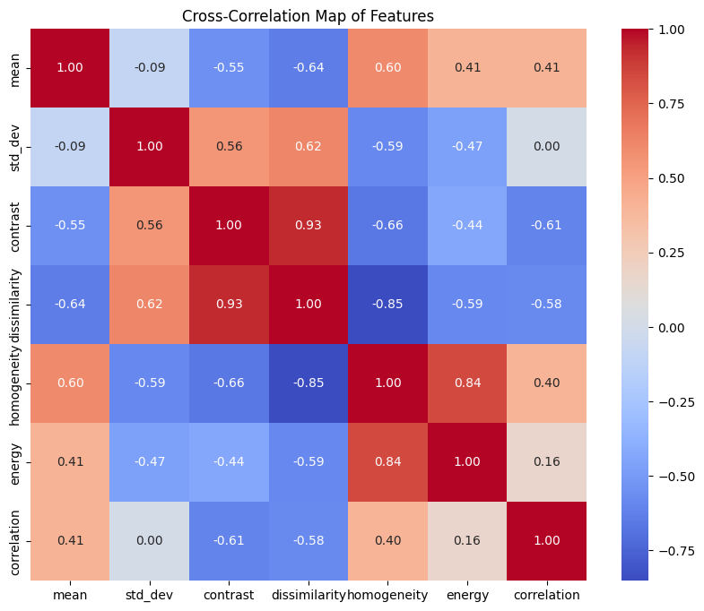

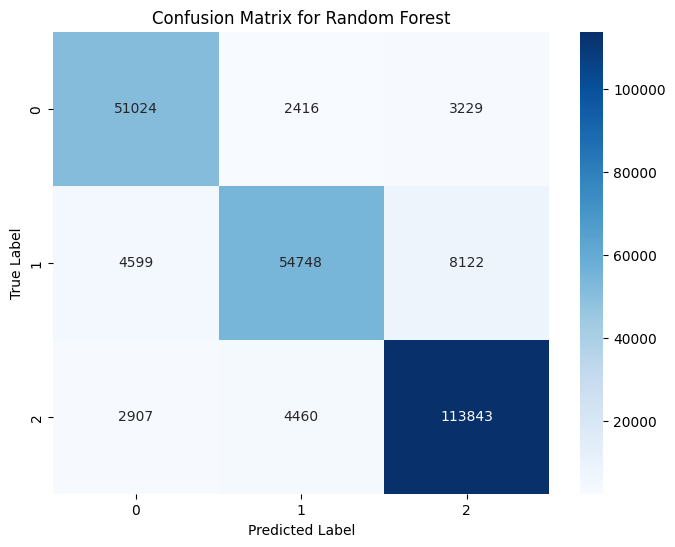

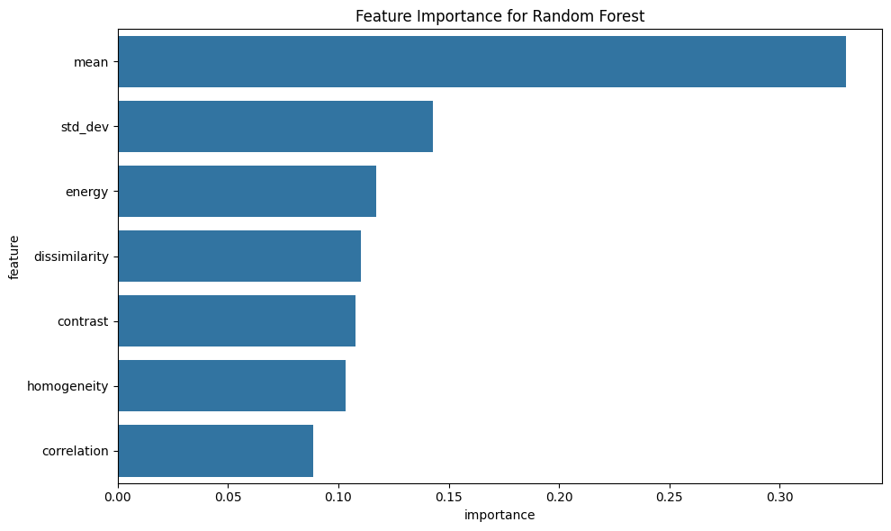

```
--- Step 4: Predicting Full Image and Calculating IoU ---
Starting full image prediction...
```

```
Full image prediction complete.

--- Segmentation Performance (IoU) ---
Class_1_IoU: 0.0039
Class_2_IoU: 0.0086
Class_3_IoU: 0.0000
Mean_IoU: 0.0042
```

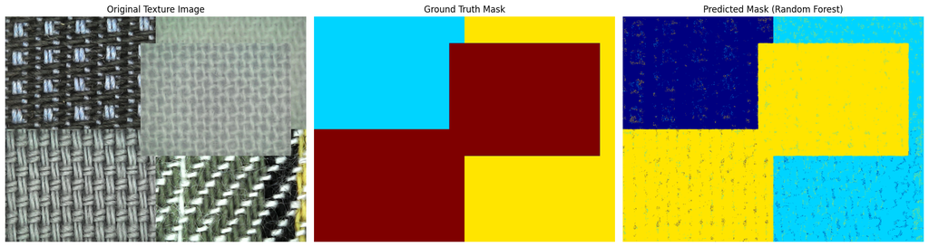

```python
# --- Step 1: Load and Preprocess Data ---
print("--- Step 1: Loading and Preprocessing Data ---")

# Load the texture image and convert to grayscale
texture_image = cv2.imread(IMAGE_PATH, cv2.IMREAD_GRAYSCALE)
# Load the color mask
mask_bgr = cv2.imread(MASK_PATH) # Önce BGR olarak yükle

# Image upload control
if texture_image is None:
    raise FileNotFoundError(f"Hata: Görüntü dosyası bulunamadı veya okunamadı. Kontrol edilecek yol: {IMAGE_PATH}")
if mask_bgr is None:
    raise FileNotFoundError(f"Hata: Maske dosyası bulunamadı veya okunamadı. Kontrol edilecek yol: {MASK_PATH}")

print("Görüntü ve maske başarıyla yüklendi.")

# Convert the color mask to integer labels
label_map = convert_color_mask_to_labels(MASK_PATH) # Fonksiyon zaten içinde okuma yapıyor, ama kontrol için yukarıdaki satırlar iyi bir pratik

print(">>> TEŞHİS: Oluşturulan Etiket Haritasındaki Benzersiz Değerler ve Sayıları:", np.unique(label_map, return_counts=True))

# Check if feature file already exists to save time
if os.path.exists(FEATURES_CSV_PATH):
    print(f"Found existing feature file '{FEATURES_CSV_PATH}'. Loading data...")
    df = pd.read_csv(FEATURES_CSV_PATH)
else:
    print(f"No feature file found. Starting extraction process...")
    # --- Step 2: Create Tabular Dataset by Feature Extraction ---
    df = extract_features_from_image(texture_image, label_map, WINDOW_SIZE)
    # Save the extracted features to a CSV file for future use
    df.to_csv(FEATURES_CSV_PATH, index=False)
    print(f"Features saved to '{FEATURES_CSV_PATH}'.")

# --- Step 3: Split Data and Preprocess ---
print("\n--- Step 2: Splitting and Scaling Data ---")
X = df.drop('label', axis=1)
y = df['label']

print(f"Orijinal etiketler: {np.unique(y)}")
y = y - 1
print(f"Dönüştürülmüş etiketler: {np.unique(y)}")

# Split the data into training and testing sets (80/20)
# Use stratify to maintain the same class distribution in train and test sets
X_train, X_test, y_train, y_test = train_test_split(
    X, y, test_size=0.2, random_state=RANDOM_SEED, stratify=y
)

print(f"Training set size: {X_train.shape[0]} samples")
print(f"Test set size: {X_test.shape[0]} samples")

# Scale features. It's crucial to fit the scaler ONLY on the training data.
scaler = StandardScaler()
X_train_scaled = scaler.fit_transform(X_train)
X_test_scaled = scaler.transform(X_test)

# Save the scaler to be reused for full image prediction
with open(SCALER_PATH, 'wb') as f:
    pickle.dump(scaler, f)
print(f"Scaler saved to '{SCALER_PATH}'.")

# --- Step 4: Train and Compare Multiple Models ---
print("\n--- Step 3: Training and Comparing Models ---")
models = {
    "Logistic Regression": LogisticRegression(random_state=RANDOM_SEED, max_iter=1000),
    "Random Forest": RandomForestClassifier(n_estimators=100, random_state=RANDOM_SEED),
    "XGBoost": xgb.XGBClassifier(use_label_encoder=False, eval_metric='mlogloss', random_state=RANDOM_SEED)
}

results = []
for name, model in models.items():
    print(f"Training {name}...")
    # Train timer
    start_train_time = time.time()
    model.fit(X_train_scaled, y_train)
    end_train_time = time.time()
    train_duration = end_train_time - start_train_time

    # Test timer
    start_test_time = time.time()
    y_pred = model.predict(X_test_scaled)
    end_test_time = time.time()
    test_duration = end_test_time - start_test_time

    accuracy = accuracy_score(y_test, y_pred)
    results.append({
        "Model": name,
        "Accuracy": accuracy,
        "Train Time (s)": train_duration,
        "Test Time (s)": test_duration
    })

results_df = pd.DataFrame(results)
print("\n--- Model Comparison ---")
print(results_df)

# --- Step 5: Analyze the Best Performing Model (based on accuracy) ---
best_model_name = results_df.loc[results_df['Accuracy'].idxmax()]['Model']
print(f"\n--- In-depth Analysis of Best Model: {best_model_name} ---")

# Train the best model again to get predictions for analysis
best_model = models[best_model_name]
best_model.fit(X_train_scaled, y_train)
y_pred_best = best_model.predict(X_test_scaled)

# Save the best model
with open(MODEL_PATH, 'wb') as f:
    pickle.dump(best_model, f)
print(f"Best model '{best_model_name}' saved to '{MODEL_PATH}'.")


# --- Visualizations ---

# 1. Feature Correlation Heatmap
plt.figure(figsize=(10, 8))
correlation_matrix = X_train.corr()
sns.heatmap(correlation_matrix, annot=True, cmap='coolwarm', fmt=".2f")
plt.title("Cross-Correlation Map of Features")
plt.show()

# 2. Confusion Matrix
cm = confusion_matrix(y_test, y_pred_best)
plt.figure(figsize=(8, 6))
sns.heatmap(cm, annot=True, fmt='d', cmap='Blues', xticklabels=np.unique(y), yticklabels=np.unique(y))
plt.title(f"Confusion Matrix for {best_model_name}")
plt.xlabel("Predicted Label")
plt.ylabel("True Label")
plt.show()

# 3. Feature Importance Plot (only for tree-based models)
if hasattr(best_model, 'feature_importances_'):
    importances = best_model.feature_importances_
    feature_names = X.columns
    feature_importance_df = pd.DataFrame({'feature': feature_names, 'importance': importances})
    feature_importance_df = feature_importance_df.sort_values('importance', ascending=False)

    plt.figure(figsize=(10, 6))
    sns.barplot(x='importance', y='feature', data=feature_importance_df)
    plt.title(f"Feature Importance for {best_model_name}")
    plt.tight_layout()
    plt.show()

# --- Step 6: Full Image Prediction and IoU Evaluation ---
print("\n--- Step 4: Predicting Full Image and Calculating IoU ---")

def predict_full_image(image_gray, model, scaler, window_size):
    """
    Predicts labels for every pixel in a full image.
    """
    print("Starting full image prediction...")
    height, width = image_gray.shape
    predicted_mask = np.zeros_like(image_gray, dtype=np.uint8)

    w_half = window_size // 2
    padded_image = np.pad(image_gray, pad_width=w_half, mode='reflect')

    # Create a batch of feature vectors for faster prediction
    all_features = []
    for y in range(height):
        for x in range(width):
            window = padded_image[y:y + window_size, x:x + window_size]

            mean = np.mean(window)
            std_dev = np.std(window)

            if np.unique(window).size > 1:
                window_quantized = (window / np.max(window) * 255).astype(np.uint8)
                glcm = graycomatrix(window_quantized, distances=[1], angles=[0, np.pi/4, np.pi/2, 3*np.pi/4], levels=256, symmetric=True, normed=True)
                contrast = graycoprops(glcm, 'contrast').mean()
                dissimilarity = graycoprops(glcm, 'dissimilarity').mean()
                homogeneity = graycoprops(glcm, 'homogeneity').mean()
                energy = graycoprops(glcm, 'energy').mean()
                correlation = graycoprops(glcm, 'correlation').mean()
            else:
                contrast, dissimilarity, homogeneity, energy, correlation = 0, 0, 1, 1, 0

            all_features.append([mean, std_dev, contrast, dissimilarity, homogeneity, energy, correlation])

    # Scale all features at once
    all_features_scaled = scaler.transform(all_features)

    # Predict all labels at once
    all_predictions = model.predict(all_features_scaled)

    # Reshape the predictions into the image mask
    predicted_mask = all_predictions.reshape((height, width))

    print("Full image prediction complete.")
    return predicted_mask

# Predict the mask for the entire texture image
predicted_label_map = predict_full_image(texture_image, best_model, scaler, WINDOW_SIZE)

def calculate_iou(true_mask, pred_mask):
    """Calculates Intersection over Union (IoU) for each class and Mean IoU."""
    iou_scores = {}
    # Get unique labels from both masks, excluding background (0)
    labels = np.unique(np.concatenate((true_mask, pred_mask)))
    labels = labels[labels != 0]

    for label in labels:
        intersection = np.sum((true_mask == label) & (pred_mask == label))
        union = np.sum((true_mask == label) | (pred_mask == label))

        if union == 0:
            iou = 1.0 # Both masks are empty for this class
        else:
            iou = intersection / union

        iou_scores[f'Class_{label}_IoU'] = iou

    # Calculate Mean IoU
    mean_iou = np.mean(list(iou_scores.values()))
    iou_scores['Mean_IoU'] = mean_iou

    return iou_scores

# Calculate IoU score
iou_results = calculate_iou(label_map, predicted_label_map)
print("\n--- Segmentation Performance (IoU) ---")
for key, value in iou_results.items():
    print(f"{key}: {value:.4f}")

# --- Final Visualization ---
fig, axes = plt.subplots(1, 3, figsize=(18, 6))
axes[0].imshow(cv2.cvtColor(cv2.imread(IMAGE_PATH), cv2.COLOR_BGR2RGB))
axes[0].set_title("Original Texture Image")
axes[0].axis('off')

axes[1].imshow(label_map, cmap='jet', vmin=0, vmax=np.max(label_map))
axes[1].set_title("Ground Truth Mask")
axes[1].axis('off')

axes[2].imshow(predicted_label_map, cmap='jet', vmin=0, vmax=np.max(label_map))
axes[2].set_title(f"Predicted Mask ({best_model_name})")
axes[2].axis('off')

plt.tight_layout()
plt.show()
```